# Apollo_case_study

###### region vs hospitalization charges

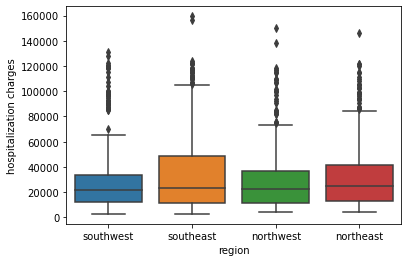

```python
sns.boxplot(data=df,x=df['region'],y=df['hospitalization charges'])
```

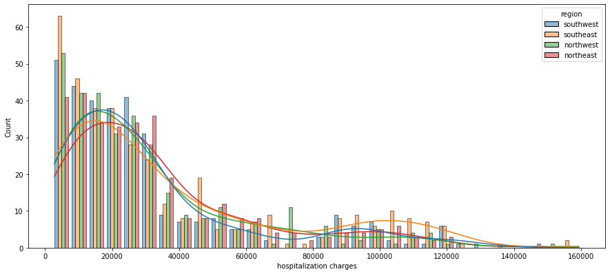

```python
plt.figure(figsize=(15, 6.5))
sns.histplot(data=df, x=df['hospitalization charges'], y=None, hue=df['region'],kde=True, multiple="dodge", shrink=0.8)
```

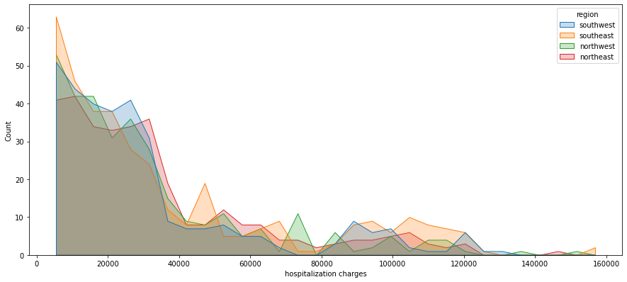

```python
plt.figure(figsize=(15, 6.5))
sns.histplot(data=df, x=df['hospitalization charges'], y=None, hue=df['region'], element='poly')
```

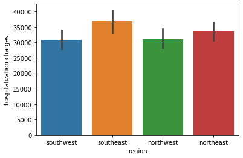

```python
sns.barplot(x = df['region'], y = df['hospitalization charges'], data=df, estimator=np.mean)
plt.show()
```

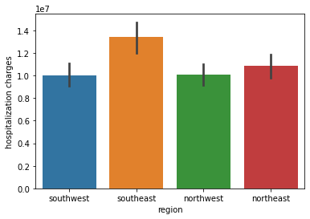

```python
sns.barplot(x = df['region'], y = df['hospitalization charges'], data=df, estimator=np.sum)
plt.show()
```

```python
df.groupby('region')['hospitalization charges'].sum()
```

```
region
northeast    10859173
northwest    10089281
southeast    13409229
southwest    10031883
Name: hospitalization charges, dtype: int64
```

```python
df.groupby('region')['hospitalization charges'].mean()
```

```
region
northeast    33515.966049
northwest    31043.941538
southeast    36838.541209
southwest    30867.332308
Name: hospitalization charges, dtype: float64
```

- Southeast and northeast People has the higest hospitalization charges

###### region vs viral_load

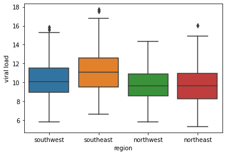

```python
sns.boxplot(data=df,x=df['region'],y=df['viral load'])
```

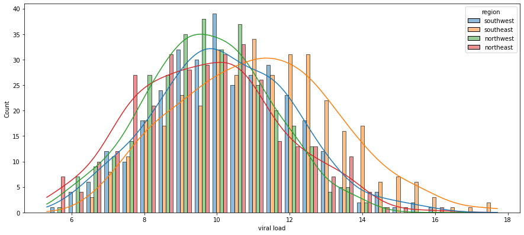

```python
plt.figure(figsize=(15, 6.5))
sns.histplot(data=df, x=df['viral load'], y=None, hue=df['region'],kde=True, multiple="dodge", shrink=0.8)
```

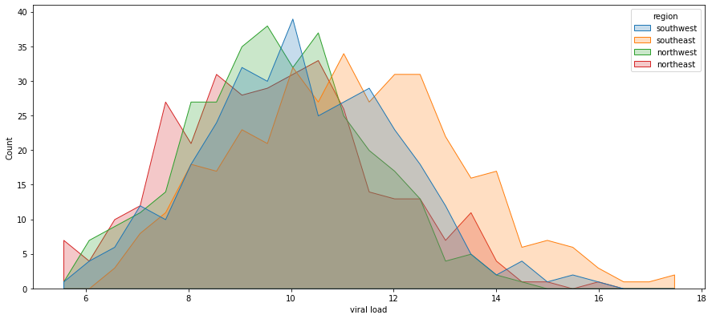

```python
plt.figure(figsize=(15, 6.5))
sns.histplot(data=df, x=df['viral load'], y=None, hue=df['region'], element='poly')
```

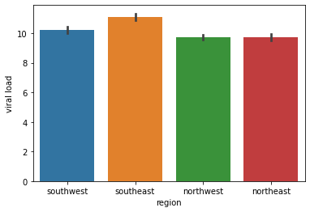

```python
sns.barplot(x = df['region'], y = df['viral load'], data=df, estimator=np.mean)
plt.show()
```

```python
df.groupby('region')['viral load'].mean()
```

```
region
northeast     9.724722
northwest     9.733508
southeast    11.118516
southwest    10.198985
Name: viral load, dtype: float64
```

- Southeast people has the higest level of viral load

###### severity level vs hospitalization charges

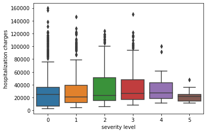

```python
sns.boxplot(data=df,x=df['severity level'],y=df['hospitalization charges'])
```

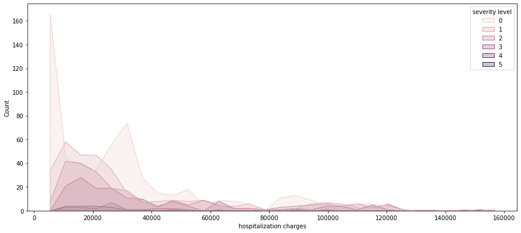

```python
plt.figure(figsize=(15, 6.5))
sns.histplot(data=df, x=df['hospitalization charges'], y=None, hue=df['severity level'], element='poly')
```

```python
df.groupby('severity level')['hospitalization charges'].mean()
```

```
severity level
0    30914.940767
1    31827.935185
2    37683.908333
3    38388.305732
4    34626.680000
5    21965.000000
Name: hospitalization charges, dtype: float64
```

- People with severity level 2 and 3 has higest hospitalization charges

###### severity level vs viral load

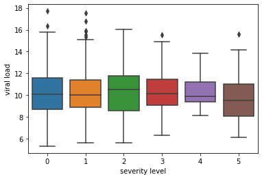

```python
sns.boxplot(data=df,x=df['severity level'],y=df['viral load'])
```

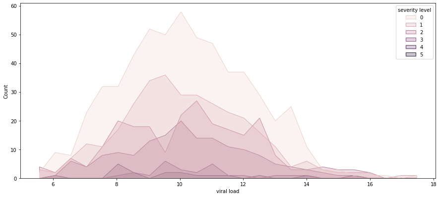

```python
plt.figure(figsize=(15, 6.5))
sns.histplot(data=df, x=df['viral load'], y=None, hue=df['severity level'], element='poly')
```

```python
df.groupby('severity level')['viral load'].mean()
```

```
severity level
0    10.183693
1    10.207562
2    10.326083
3    10.228217
4    10.464000
5     9.868333
Name: viral load, dtype: float64
```

###### Age vs hospitalization charges

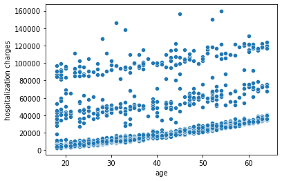

```python
sns.scatterplot(x=df['age'],y=df['hospitalization charges'])
```

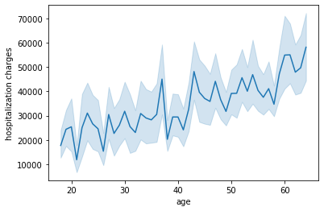

```python
sns.lineplot(x=df['age'],y=df['hospitalization charges'])
```

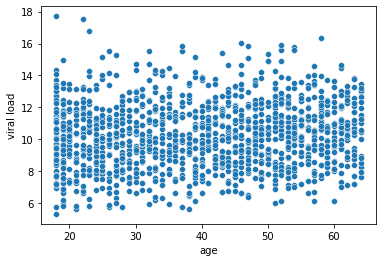

```python
sns.scatterplot(x=df['age'],y=df['viral load'])
```

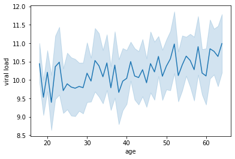

```python
sns.lineplot(x=df['age'],y=df['viral load'])
```

## Multivariate Analysis

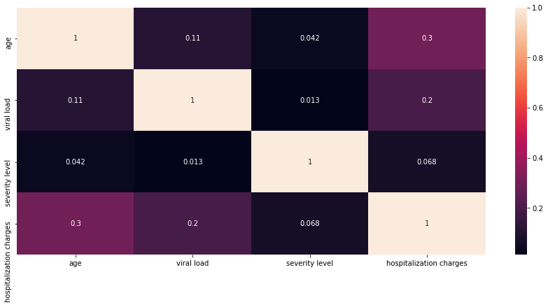

```python
plt.figure(figsize=(15, 6.5))
sns.heatmap(df.select_dtypes(exclude='object').corr(),annot=True)
```

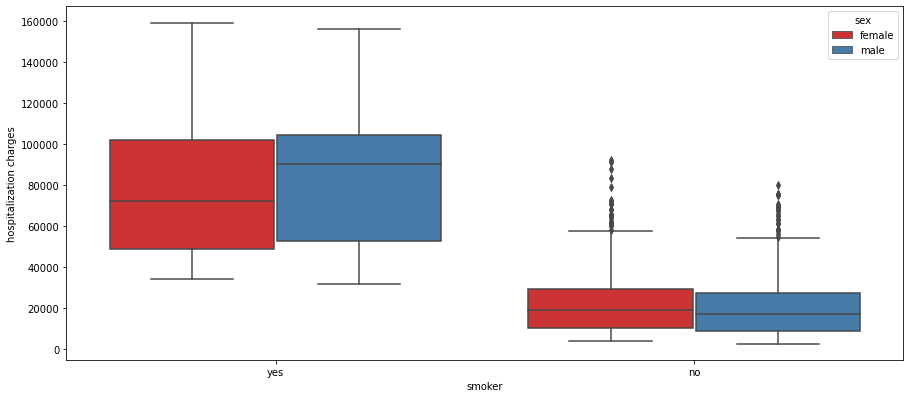

```python
plt.figure(figsize=(15, 6.5))
sns.boxplot(data=df, y=df['hospitalization charges'], x=df['smoker'], hue='sex', palette='Set1')
```

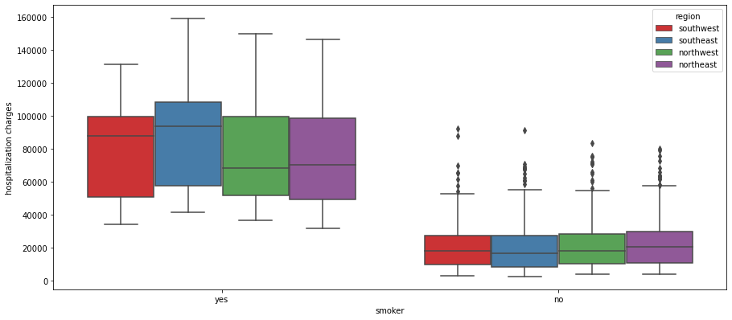

```python
plt.figure(figsize=(15, 6.5))
sns.boxplot(data=df, y=df['hospitalization charges'], x=df['smoker'], hue=df['region'], palette='Set1')
```

```python
df_smoker_plus_region=df.groupby(['smoker','region'])['hospitalization charges'].mean()
df_smoker_plus_region
```

```
smoker  region
no      northeast    22913.836576
        northwest    21391.176030
        southeast    20080.553114
        southwest    20048.194757
yes     northeast    74183.835821
        northwest    75479.948276
        southeast    87112.505495
        southwest    80672.672414
Name: hospitalization charges, dtype: float64
```

- Out of all the people who smokes, Southeast people has the higest hospitalization charges
- And Out of all the people who don't smokes, Northeast people has the higest hospitalization charges

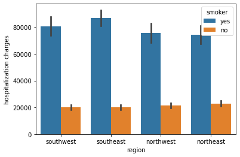

```python
sns.barplot(x = df['region'], y = df['hospitalization charges'], data=df, estimator=np.mean,hue=df['smoker'])
plt.show()
```

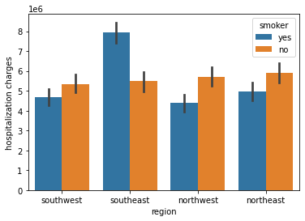

```python
sns.barplot(x = df['region'], y = df['hospitalization charges'], data=df,hue=df['smoker'] ,estimator=np.sum)
plt.show()
```

- net revenue in southeasat region is highest

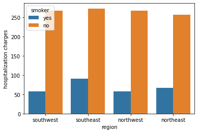

```python
sns.barplot(x = df['region'], y = df['hospitalization charges'], data=df,hue=df['smoker'] ,estimator=np.count_nonzero)
plt.show()
```

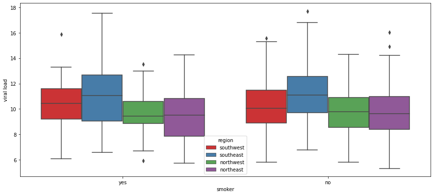

```python
plt.figure(figsize=(15, 6.5))
sns.boxplot(data=df, y=df['viral load'], x=df['smoker'], hue=df['region'], palette='Set1')
```

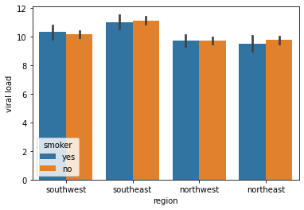

```python
sns.barplot(x = df['region'], y = df['viral load'], data=df, estimator=np.mean,hue=df['smoker'])
plt.show()
```

- No matter if a person is smoker or non-smoker, southeast people has highest viral load

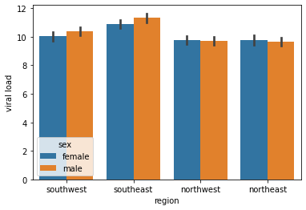

```python
sns.barplot(x = df['region'], y = df['viral load'], data=df, estimator=np.mean,hue=df['sex'])
plt.show()
```

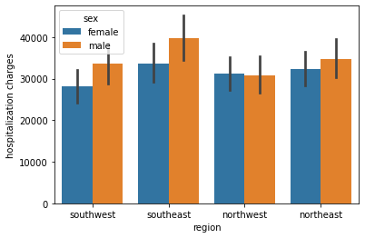

```python
sns.barplot(x = df['region'], y = df['hospitalization charges'], data=df, estimator=np.mean,hue=df['sex'])
plt.show()
```

```python
df_smoker_plus_region=df.groupby(['smoker','region'])['hospitalization charges'].sum()
df_smoker_plus_region
```

```
smoker  region
no      northeast    5888856
        northwest    5711444
        southeast    5481991
        southwest    5352868
yes     northeast    4970317
        northwest    4377837
        southeast    7927238
        southwest    4679015
Name: hospitalization charges, dtype: int64
```

```python
df_smoker_plus_region=df.groupby(['sex','region'])['hospitalization charges'].mean()
df_smoker_plus_region
```

```
sex     region
female  northeast    32383.018634
        northwest    31199.689024
        southeast    33749.194286
        southwest    28185.975309
male    northeast    34635.012270
        northwest    30885.291925
        southeast    39699.047619
        southwest    33532.239264
Name: hospitalization charges, dtype: float64
```

- Females hospitalization charges is more in northwest

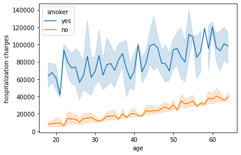

```python
sns.lineplot(x=df['age'],y=df['hospitalization charges'],hue=df['smoker'])
```

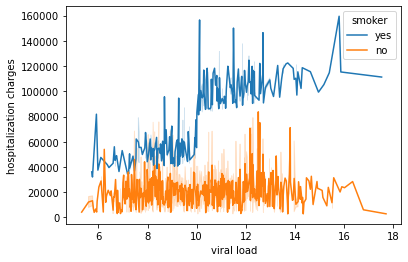

```python
sns.lineplot(x=df['viral load'],y=df['hospitalization charges'],hue=df['smoker'])
```

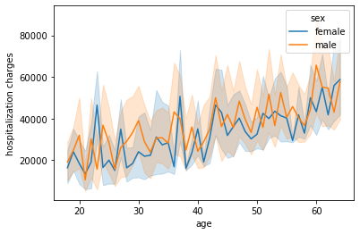

```python
sns.lineplot(x=df['age'],y=df['hospitalization charges'],hue=df['sex'])
```